# Исследование закономерностей, определяющих успешность игры

**Цель исследования:**

Выявить определяющие успешность игры закономерности чтобы сделать ставку на потенциально популярный продукт и спланировать рекламные кампании.

## Знакомство с данными

```python
import pandas as pd
import seaborn as sns
import matplotlib.pyplot as plt
import numpy as np
from scipy import stats as st
import warnings
warnings.filterwarnings('ignore')
warnings.simplefilter('ignore')
```

```python
data = pd.read_csv('/datasets/games.csv')
```

```python
data.head()
```

|  | Name | Platform | Year_of_Release | Genre | NA_sales | EU_sales | JP_sales | Other_sales | Critic_Score | User_Score | Rating |
| --- | --- | --- | --- | --- | --- | --- | --- | --- | --- | --- | --- |
| 0 | Wii Sports | Wii | 2006.0 | Sports | 41.36 | 28.96 | 3.77 | 8.45 | 76.0 | 8 | E |
| 1 | Super Mario Bros. | NES | 1985.0 | Platform | 29.08 | 3.58 | 6.81 | 0.77 | NaN | NaN | NaN |
| 2 | Mario Kart Wii | Wii | 2008.0 | Racing | 15.68 | 12.76 | 3.79 | 3.29 | 82.0 | 8.3 | E |
| 3 | Wii Sports Resort | Wii | 2009.0 | Sports | 15.61 | 10.93 | 3.28 | 2.95 | 80.0 | 8 | E |
| 4 | Pokemon Red/Pokemon Blue | GB | 1996.0 | Role-Playing | 11.27 | 8.89 | 10.22 | 1.00 | NaN | NaN | NaN |

```python
data.info()
```

```
<class 'pandas.core.frame.DataFrame'>
RangeIndex: 16715 entries, 0 to 16714
Data columns (total 11 columns):
 #   Column           Non-Null Count  Dtype
---  ------           --------------  -----
 0   Name             16713 non-null  object
 1   Platform         16715 non-null  object
 2   Year_of_Release  16446 non-null  float64
 3   Genre            16713 non-null  object
 4   NA_sales         16715 non-null  float64
 5   EU_sales         16715 non-null  float64
 6   JP_sales         16715 non-null  float64
 7   Other_sales      16715 non-null  float64
 8   Critic_Score     8137 non-null   float64
 9   User_Score       10014 non-null  object
 10  Rating           9949 non-null   object
dtypes: float64(6), object(5)
memory usage: 1.4+ MB
```

User_Score и Rating типа object

```python
data.describe()
```

|  | Year_of_Release | NA_sales | EU_sales | JP_sales | Other_sales | Critic_Score |
| --- | --- | --- | --- | --- | --- | --- |
| count | 16446.000000 | 16715.000000 | 16715.000000 | 16715.000000 | 16715.000000 | 8137.000000 |
| mean | 2006.484616 | 0.263377 | 0.145060 | 0.077617 | 0.047342 | 68.967679 |
| std | 5.877050 | 0.813604 | 0.503339 | 0.308853 | 0.186731 | 13.938165 |
| min | 1980.000000 | 0.000000 | 0.000000 | 0.000000 | 0.000000 | 13.000000 |
| 25% | 2003.000000 | 0.000000 | 0.000000 | 0.000000 | 0.000000 | 60.000000 |
| 50% | 2007.000000 | 0.080000 | 0.020000 | 0.000000 | 0.010000 | 71.000000 |
| 75% | 2010.000000 | 0.240000 | 0.110000 | 0.040000 | 0.030000 | 79.000000 |
| max | 2016.000000 | 41.360000 | 28.960000 | 10.220000 | 10.570000 | 98.000000 |

```python
data.duplicated().sum()
```

```
0
```

Сразу исправим названия столбцов на более удобные

```python
columns = ['name', 'platform', 'year_of_release', 'genre', 'na_sales', 'eu_sales', 'jp_sales', 'other_sales', 'critic_score', 'user_score', 'rating']
data.columns = columns
```

## Подготовка данных

### Пропуски и типы данных

Для начала, посмотрим на количество пропусков.

```python
data.isna().sum()
```

```
name                  2
platform              0
year_of_release     269
genre                 2
na_sales              0
eu_sales              0
jp_sales              0
other_sales           0
critic_score       8578
user_score         6701
rating             6766
dtype: int64
```

Рассмотрим строки с пропуском в названии:

```python
data.query('name.isna()')
```

|  | name | platform | year_of_release | genre | na_sales | eu_sales | jp_sales | other_sales | critic_score | user_score | rating |
| --- | --- | --- | --- | --- | --- | --- | --- | --- | --- | --- | --- |
| 659 | NaN | GEN | 1993.0 | NaN | 1.78 | 0.53 | 0.00 | 0.08 | NaN | NaN | NaN |
| 14244 | NaN | GEN | 1993.0 | NaN | 0.00 | 0.00 | 0.03 | 0.00 | NaN | NaN | NaN |

Это те же 2 игры, для которых отсутствует и жанр. Удалим эти строки, так как и оценки, и рейтинг для этих игр отсутствует, они ничем не полезны для анализа.

```python
data = data.dropna(subset=['name'])
data = data.reset_index(drop=True)
```

Рассмотрим поближе данные по оценкам, чтобы понять, почему строка **user_score** имеет тип *object*, и во всех ли случаях **critic_score** -- целочисленное значение, как и в первых 5 строках таблицы.

```python
data.critic_score.unique()
```

```
array([76., nan, 82., 80., 89., 58., 87., 91., 61., 97., 95., 77., 88.,
       83., 94., 93., 85., 86., 98., 96., 90., 84., 73., 74., 78., 92.,
       71., 72., 68., 62., 49., 67., 81., 66., 56., 79., 70., 59., 64.,
       75., 60., 63., 69., 50., 25., 42., 44., 55., 48., 57., 29., 47.,
       65., 54., 20., 53., 37., 38., 33., 52., 30., 32., 43., 45., 51.,
       40., 46., 39., 34., 35., 41., 36., 28., 31., 27., 26., 19., 23.,
       24., 21., 17., 22., 13.])
```

```python
data.user_score.unique()
```

```
array(['8', nan, '8.3', '8.5', '6.6', '8.4', '8.6', '7.7', '6.3', '7.4',
       '8.2', '9', '7.9', '8.1', '8.7', '7.1', '3.4', '5.3', '4.8', '3.2',
       '8.9', '6.4', '7.8', '7.5', '2.6', '7.2', '9.2', '7', '7.3', '4.3',
       '7.6', '5.7', '5', '9.1', '6.5', 'tbd', '8.8', '6.9', '9.4', '6.8',
       '6.1', '6.7', '5.4', '4', '4.9', '4.5', '9.3', '6.2', '4.2', '6',
       '3.7', '4.1', '5.8', '5.6', '5.5', '4.4', '4.6', '5.9', '3.9',
       '3.1', '2.9', '5.2', '3.3', '4.7', '5.1', '3.5', '2.5', '1.9', '3',
       '2.7', '2.2', '2', '9.5', '2.1', '3.6', '2.8', '1.8', '3.8', '0',
       '1.6', '9.6', '2.4', '1.7', '1.1', '0.3', '1.5', '0.7', '1.2',
       '2.3', '0.5', '1.3', '0.2', '0.6', '1.4', '0.9', '1', '9.7'],
      dtype=object)
```

Для оценок так же понадобится заглушка. Так как оценка "0" встречается в базе данных, заменим пропуски на -1.

В столбце **user_score** встречается значение *tbd*, эта аббревиатура расшифровывается как "to be determined", она означает, что данных еще нет и мешает поменять тип данных в данном столбце на *float*. Заменим ее, как и пропуски, на -1.

Тут же изменим типы данных:

- для столбца с годом выпуска - *int*
- для столбца с оценками критиков - *int* (все значения целочисленные, нет смысла оставлять тип float)
- для столбца с оценками пользователей - *float*

```python
data=data.dropna(subset=['year_of_release'])

data.loc[data['user_score'] == 'tbd', 'user_score'] =  -1
data['user_score'] = data['user_score'].fillna(-1)
data['user_score'] = data['user_score'].astype('float')

data['critic_score'] = data['critic_score'].fillna(-1)
data['critic_score'] = data['critic_score'].astype('int')

data['rating'] = data['rating'].fillna('unknown')
```

Рейтинг просто заменим на *unknown*: пропущенных значений слишком много, чтобы их удалять, а замена этих значений на предполагаемые может повлиять на результаты анализа.

```python
no_rate = data.query('rating.isna()')
print(no_rate.count())
print(no_rate.query('user_score == -1').count())
print(no_rate.query('critic_score == -1').count())
```

```
name               0
platform           0
year_of_release    0
genre              0
na_sales           0
eu_sales           0
jp_sales           0
other_sales        0
critic_score       0
user_score         0
rating             0
dtype: int64
name               0
platform           0
year_of_release    0
genre              0
na_sales           0
eu_sales           0
jp_sales           0
other_sales        0
critic_score       0
user_score         0
rating             0
dtype: int64
name               0
platform           0
year_of_release    0
genre              0
na_sales           0
eu_sales           0
jp_sales           0
other_sales        0
critic_score       0
user_score         0
rating             0
dtype: int64
```

### Суммарные продажи

Добавим столбец с суммарными продажами для всех регионов.

```python
data['total_sales'] = data['na_sales'] + data['eu_sales'] + data['jp_sales'] + data['other_sales']
```

```python
data.head()
```

|  | name | platform | year_of_release | genre | na_sales | eu_sales | jp_sales | other_sales | critic_score | user_score | rating | total_sales |
| --- | --- | --- | --- | --- | --- | --- | --- | --- | --- | --- | --- | --- |
| 0 | Wii Sports | Wii | 2006.0 | Sports | 41.36 | 28.96 | 3.77 | 8.45 | 76 | 8.0 | E | 82.54 |
| 1 | Super Mario Bros. | NES | 1985.0 | Platform | 29.08 | 3.58 | 6.81 | 0.77 | -1 | -1.0 | unknown | 40.24 |
| 2 | Mario Kart Wii | Wii | 2008.0 | Racing | 15.68 | 12.76 | 3.79 | 3.29 | 82 | 8.3 | E | 35.52 |
| 3 | Wii Sports Resort | Wii | 2009.0 | Sports | 15.61 | 10.93 | 3.28 | 2.95 | 80 | 8.0 | E | 32.77 |
| 4 | Pokemon Red/Pokemon Blue | GB | 1996.0 | Role-Playing | 11.27 | 8.89 | 10.22 | 1.00 | -1 | -1.0 | unknown | 31.38 |

Данные готовы к анализу.

## Исследовательский анализ

### Актуальный период

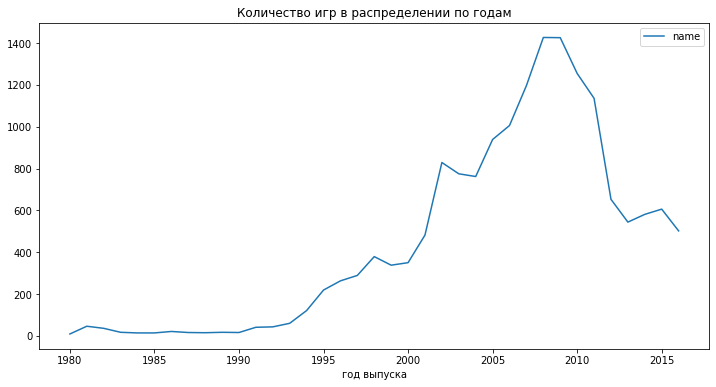

```python
games_per_year = data.groupby('year_of_release')[['name']].count()

games_per_year.query('year_of_release > 0').plot(figsize=(12, 6), xlabel = ('год выпуска'), title=('Количество игр в распределении по годам'))
None
```

На графике заметны 3 скачка: в 1995, 2000 и 2005 году.

Оставим данные начиная с 2000 года, так как тогда и произошел самый резкий скачок.

```python
data_new = data.query('year_of_release >= 2000')
```

Посмотрим, как менялись продажи по платформам. Для этого необходимо выберать платформы с наибольшими суммарными продажами и построить распределение по годам.

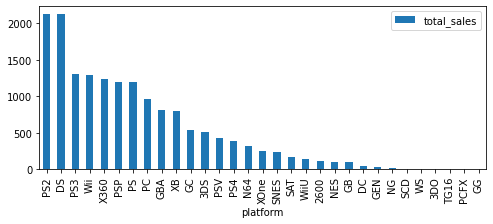

```python
data.groupby('platform')[['total_sales']].count().sort_values(by='total_sales', ascending=False).plot(kind='bar', figsize=(8, 3))
```

Возьмем первые 6 платформ, т.к. далее идет PS, статистика по которому будет неактуальна для того, чтобы делать прогнозы, т.к. платформа была устаревшей даже на 2016 год.

```python
top_platforms = data.groupby('platform')[['total_sales']].count().sort_values(by='total_sales', ascending=False)[:6].index.tolist()
data_top_6 = data_new.query('platform in @top_platforms')
data_top_6 = data_top_6.reset_index(drop=True)
```

**data_top_6** содержит только данные по 6 самым популярным платформам

```python
grouped = data_top_6.groupby(['platform', 'year_of_release']).agg({'total_sales': 'sum'})
grouped.head()
```

| platform | year_of_release | total_sales |
| --- | --- | --- |
| DS | 2004.0 | 17.27 |
|  | 2005.0 | 130.14 |
|  | 2006.0 | 119.81 |
|  | 2007.0 | 146.94 |
|  | 2008.0 | 145.31 |

**grouped** содержит общие продажи для каждой из 6 наиболее популярных платформ по годам.

Сразу избавимся от мультииндекса. И построим график распределения продаж для каждой платформы по годам.

```python
grouped = grouped.reset_index()
```

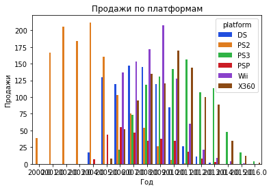

```python
colors = sns.color_palette("bright")[:data.platform.nunique()]
ax = sns.barplot(x='year_of_release',
            y='total_sales',
            hue="platform", palette=colors,
            data=grouped)

sns.set(rc = {'figure.figsize':(30,10)})
ax.set_title('Продажи по платформам')
ax.set(xlabel='Год', ylabel='Продажи');
```

По графику можно сделать вывод, что платформа в среднем "живёт" 9-10 лет.

Платформы, существовавшие даже в 2007 так же будут неактуальны, в 2017 они уже будут устаревшими.

Соответственно, раз нам нужно сделать прогноз на 2017 год, нам нужны только данные начиная с 2012 года. Это позволит исключить платформы, которые будут уже на закате своей жизни к 2017, а так же платформы, которые стали устаревшими еще, например, в 2009.

2012-2016 -- наш **актуальный период**.

```python
rel_data = data.query('year_of_release > 2011')
```

### Перспективные платформы

Мы выяснили, что "продолжительность жизни" каждой платформы в среднем составляет 10 лет. Отсортируем актуальные данные:

```python
rel_grouped = rel_data.groupby(['platform', 'year_of_release']).agg({'total_sales': 'sum'}).reset_index()
rel_grouped
```

|  | platform | year_of_release | total_sales |
| --- | --- | --- | --- |
| 0 | 3DS | 2012.0 | 51.36 |
| 1 | 3DS | 2013.0 | 56.57 |
| 2 | 3DS | 2014.0 | 43.76 |
| 3 | 3DS | 2015.0 | 27.78 |
| 4 | 3DS | 2016.0 | 15.14 |
| 5 | DS | 2012.0 | 11.01 |
| 6 | DS | 2013.0 | 1.54 |
| 7 | PC | 2012.0 | 23.22 |
| 8 | PC | 2013.0 | 12.38 |
| 9 | PC | 2014.0 | 13.28 |
| 10 | PC | 2015.0 | 8.52 |
| 11 | PC | 2016.0 | 5.25 |
| 12 | PS3 | 2012.0 | 107.36 |
| 13 | PS3 | 2013.0 | 113.25 |
| 14 | PS3 | 2014.0 | 47.76 |
| 15 | PS3 | 2015.0 | 16.82 |
| 16 | PS3 | 2016.0 | 3.60 |
| 17 | PS4 | 2013.0 | 25.99 |
| 18 | PS4 | 2014.0 | 100.00 |
| 19 | PS4 | 2015.0 | 118.90 |
| 20 | PS4 | 2016.0 | 69.25 |
| 21 | PSP | 2012.0 | 7.69 |
| 22 | PSP | 2013.0 | 3.14 |
| 23 | PSP | 2014.0 | 0.24 |
| 24 | PSP | 2015.0 | 0.12 |
| 25 | PSV | 2012.0 | 16.19 |
| 26 | PSV | 2013.0 | 10.59 |
| 27 | PSV | 2014.0 | 11.90 |
| 28 | PSV | 2015.0 | 6.25 |
| 29 | PSV | 2016.0 | 4.25 |
| 30 | Wii | 2012.0 | 21.71 |
| 31 | Wii | 2013.0 | 8.59 |
| 32 | Wii | 2014.0 | 3.75 |
| 33 | Wii | 2015.0 | 1.14 |
| 34 | Wii | 2016.0 | 0.18 |
| 35 | WiiU | 2012.0 | 17.56 |
| 36 | WiiU | 2013.0 | 21.65 |
| 37 | WiiU | 2014.0 | 22.03 |
| 38 | WiiU | 2015.0 | 16.35 |
| 39 | WiiU | 2016.0 | 4.60 |
| 40 | X360 | 2012.0 | 99.74 |
| 41 | X360 | 2013.0 | 88.58 |
| 42 | X360 | 2014.0 | 34.74 |
| 43 | X360 | 2015.0 | 11.96 |
| 44 | X360 | 2016.0 | 1.52 |
| 45 | XOne | 2013.0 | 18.96 |
| 46 | XOne | 2014.0 | 54.07 |
| 47 | XOne | 2015.0 | 60.14 |
| 48 | XOne | 2016.0 | 26.15 |

Рассмотрим график общих продаж для разных платформ.

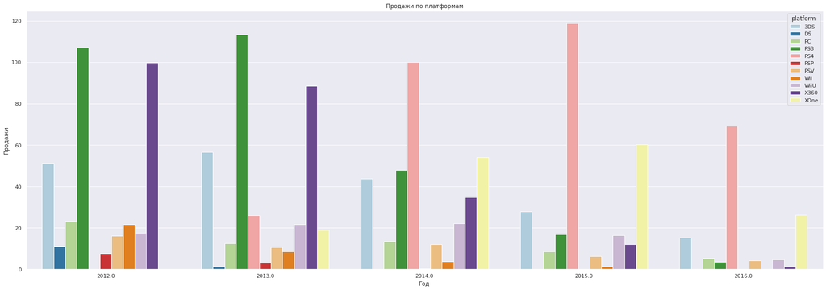

```python
colors = sns.color_palette("Paired")[:rel_data.platform.nunique()]
ax = sns.barplot(x='year_of_release',
            y='total_sales',
            hue="platform", palette=colors,
            data=rel_grouped)

sns.set(rc = {'figure.figsize':(30,8)})
ax.set_title('Продажи по платформам')
ax.set(xlabel='Год', ylabel='Продажи');
```

Потенциально прибыльными можно назвать разве что 2 платформы: XOne и PS4. С натяжкой можно добавить в этот список 3DS, у остальных платформ продажи на 2016 год примерно на одном уровне.

### Продажи по платформам

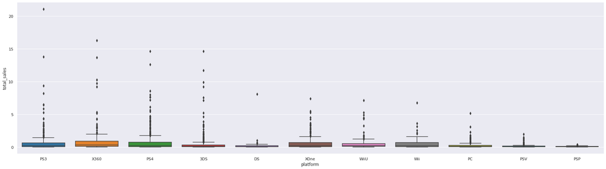

```python
colors = sns.color_palette("tab10")[:rel_data.platform.nunique()]
sns.boxplot(x='platform', y='total_sales', data=rel_data, notch=False, palette = colors)
```

[output not shown]

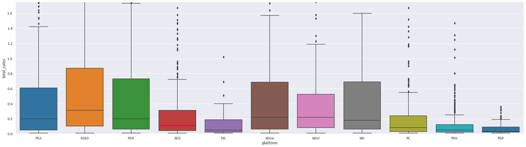

```python
sns.boxplot(x='platform', y='total_sales', data=rel_data, notch=False, palette = colors)
plt.ylim(0, 1.75)
```

Выводы:

- Лучшие результаты показывают платформы X360, PS4, XOne, PS3 и Wii, у этих платформ самые высокие медианы и третий квартиль.
- Если убрать ограничения для графика, можно увидеть, что почти у всех платформ были свои "хиты" в виде выбросов. Именно из-за этого график пришлось сильно ограничить.

### Корелляция отзывов и продаж

Выясним, есть ли зависимость между отзывами и продажами игр.

Для этого:

- сделаем срез, отсеяв все платформы кроме PS4 и замененные нами ранее на *-1* пропущенные значения
- построим диаграму рассеяния и тепловую карту

[output not shown]

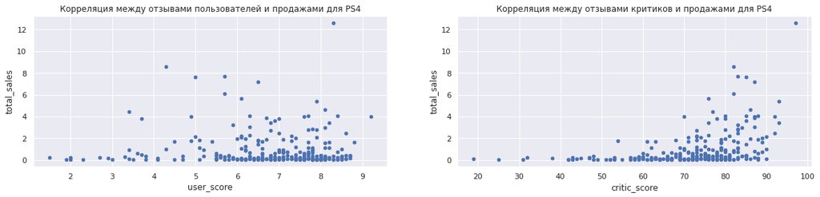

```python
cols_corr = ['total_sales', 'user_score', 'critic_score']
ps4_corr = rel_data.query('platform == "PS4"').query('user_score>0').query('critic_score>0').reset_index()
cols_user = ['total_sales', 'user_score']
ps4_users = rel_data.query('platform == "PS4"').query('user_score>0')[cols_user].reset_index()
fig, axes = plt.subplots(ncols=2, figsize = (20,4))
ps4_users.plot(ax=axes[0], x = 'user_score', y = 'total_sales', kind = 'scatter', subplots=True, legend = False);
axes[0].set_title('Корреляция между отзывами пользователей и продажами для PS4')
None
cols_critic= ['total_sales', 'critic_score']
ps4_critic = rel_data.query('platform == "PS4"').query('critic_score>0')[cols_critic].reset_index()
ps4_critic.plot(ax=axes[1], x = 'critic_score', y = 'total_sales', kind = 'scatter', subplots=True, legend = False);
axes[1].set_title('Корреляция между отзывами критиков и продажами для PS4')
None
```

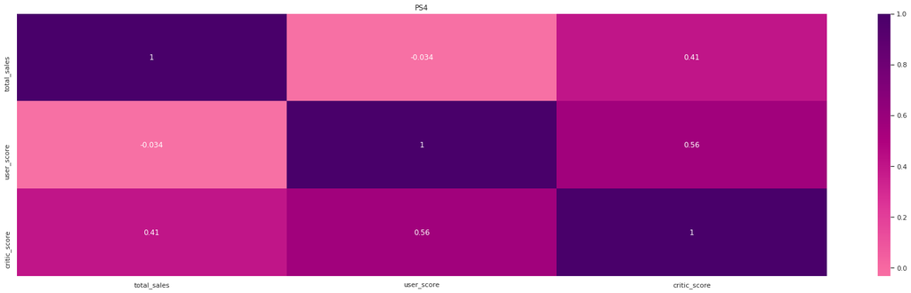

```python
ax = plt.axes()
sns.heatmap(ps4_corr[cols_corr].corr(), xticklabels=ps4_corr[cols_corr].corr(), yticklabels=ps4_corr[cols_corr].corr(), cmap='RdPu', center=0, annot=True, ax=ax)
ax.set_title('PS4')
None
```

О какой-то зависимости говорить трудно, корелляция между оценками критиков и продажами слабая (0,41), а между оценками пользователей и продажами практически отсутствует, к тому же она отрицательная (-0,034).

Проверим, актуально ли это для других платформ.

[output not shown]

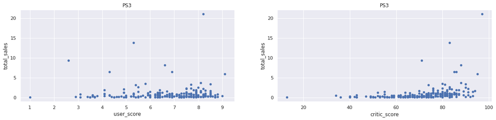

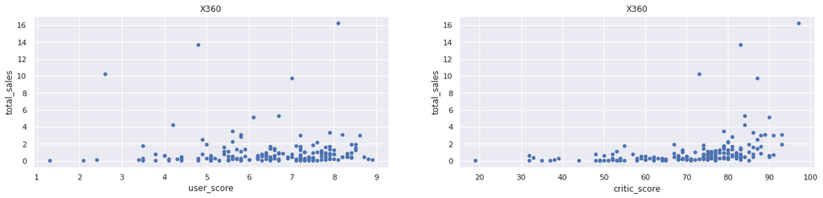

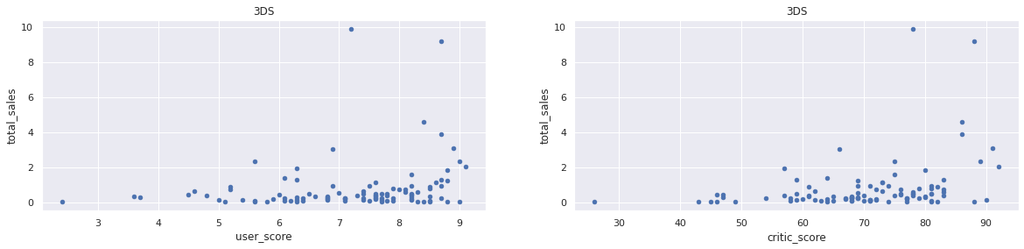

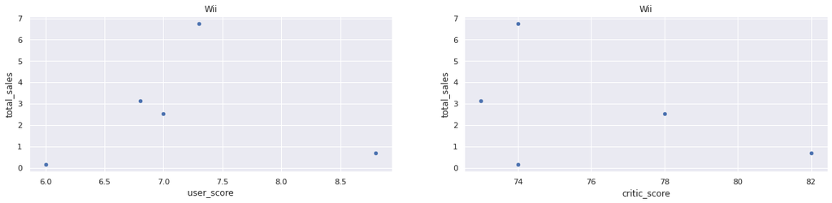

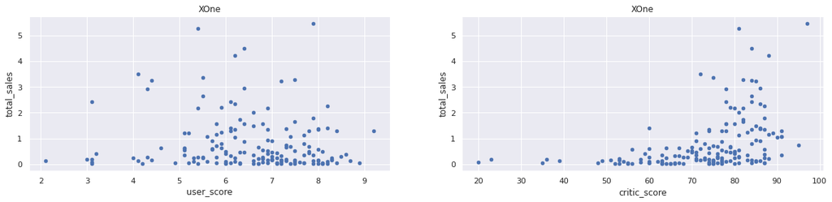

```python
corr_data = rel_data.query('user_score>0').query('critic_score>0').reset_index()
cols_corr = ['platform', 'total_sales', 'user_score', 'critic_score']
corr_data = corr_data[cols_corr]

cols_user = ['total_sales', 'user_score']
columns=['total_sales', 'user_score', 'critic_score']
pfs = ['PS3', 'XOne', 'X360', '3DS', 'Wii']
corr_data = corr_data.query('platform in @pfs')
for pf in corr_data['platform'].unique():
    ds=corr_data.query('platform == @pf')
    pf_users = ds[cols_user].reset_index()
    fig, axes = plt.subplots(ncols=2, figsize = (20,4))
    pf_users.plot(ax=axes[0], x = 'user_score', y = 'total_sales', kind = 'scatter', subplots=True, legend = False);
    axes[0].set_title(pf)
    None
    cols_critic= ['total_sales', 'critic_score']
    pf_critics = ds[cols_critic].reset_index()
    pf_critics.plot(ax=axes[1], x = 'critic_score', y = 'total_sales', kind = 'scatter', subplots=True, legend = False);
    axes[1].set_title(pf)
    None
```

|  | total_sales | user_score | critic_score |
| --- | --- | --- | --- |
| total_sales | 1.000000 | 0.003227 | 0.331057 |
| user_score | 0.003227 | 1.000000 | 0.539456 |
| critic_score | 0.331057 | 0.539456 | 1.000000 |

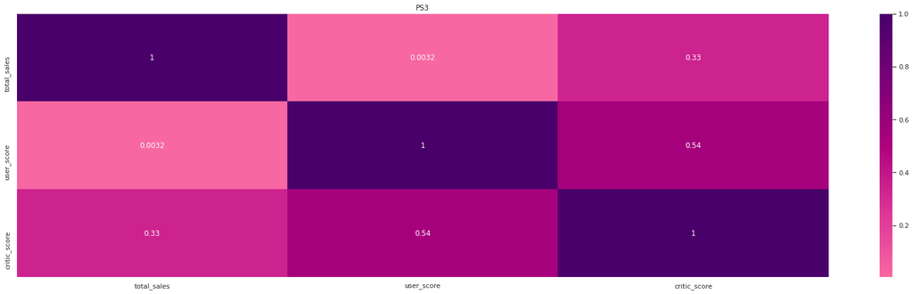

|  | total_sales | user_score | critic_score |
| --- | --- | --- | --- |
| total_sales | 1.000000 | -0.002014 | 0.360573 |
| user_score | -0.002014 | 1.000000 | 0.557352 |
| critic_score | 0.360573 | 0.557352 | 1.000000 |

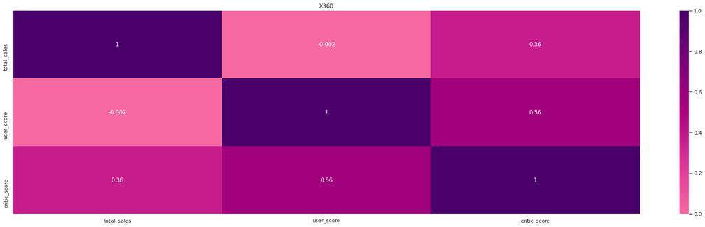

|  | total_sales | user_score | critic_score |
| --- | --- | --- | --- |
| total_sales | 1.000000 | 0.201813 | 0.310553 |
| user_score | 0.201813 | 1.000000 | 0.722762 |
| critic_score | 0.310553 | 0.722762 | 1.000000 |

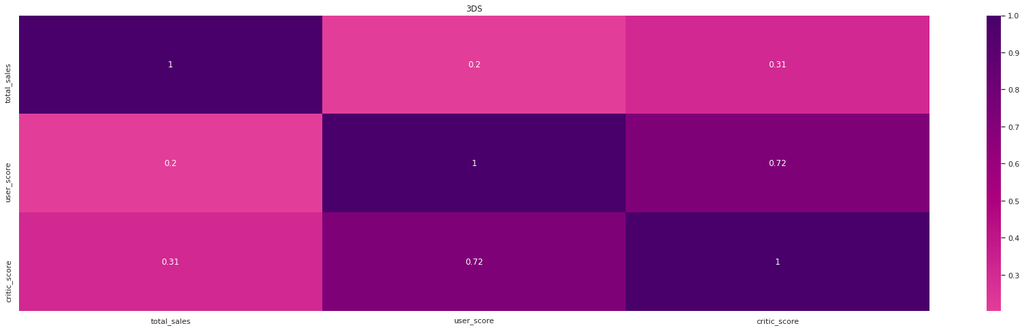

|  | total_sales | user_score | critic_score |
| --- | --- | --- | --- |
| total_sales | 1.000000 | 0.009756 | -0.424341 |
| user_score | 0.009756 | 1.000000 | 0.816295 |
| critic_score | -0.424341 | 0.816295 | 1.000000 |

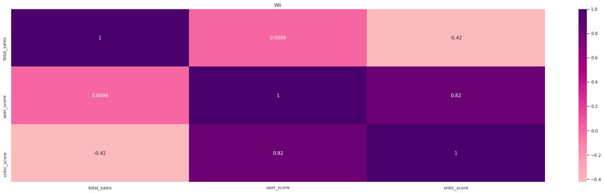

|  | total_sales | user_score | critic_score |
| --- | --- | --- | --- |
| total_sales | 1.000000 | -0.094003 | 0.410422 |
| user_score | -0.094003 | 1.000000 | 0.472462 |
| critic_score | 0.410422 | 0.472462 | 1.000000 |

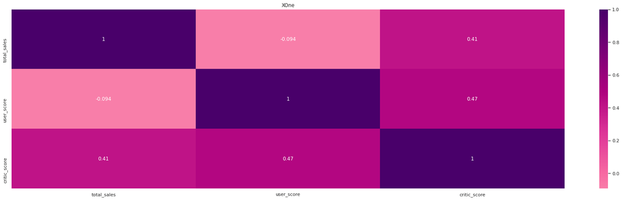

```python
columns=['total_sales', 'user_score', 'critic_score']
pfs = ['PS3', 'XOne', 'X360', '3DS', 'Wii']
corr_data = corr_data.query('platform in @pfs')
for i in corr_data['platform'].unique():
    ds=corr_data.query('platform == @i')
    display(ds[columns].corr())
    ax = plt.axes()
    sns.heatmap(ds[columns].corr(), xticklabels=ds[columns].corr(), yticklabels=ds[columns].corr(), cmap='RdPu', center=0, annot=True, ax=ax)
    ax.set_title(i)
    plt.show()
```

В целом, картины похожие, однако, в случае с **Wii** можно заметить отрицательную корреляцию между отзывами критиков и продажами. Но игр на Wii с отзывами крайне мало, так что выборку нельзя считать репрезентативной.

### Распределения игр по жанрам

Посмотрим, какие жанры встречаются чаще всего, а так же, какие жанры можно назвать наиболее и наименее прибыльными.

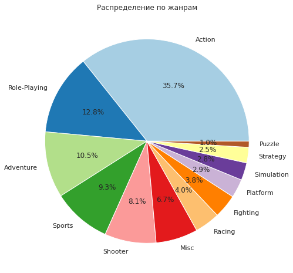

```python
by_genres = rel_data.groupby('genre').agg({'name': 'count'}).sort_values(by='name', ascending=False).reset_index()
fig, ax = plt.subplots()
colors = sns.color_palette("Paired")[:by_genres.genre.nunique()]
ax.pie(by_genres['name'], labels=by_genres['genre'], colors = colors, autopct='%1.1f%%')
ax.set_title('Распределение по жанрам')
None
```

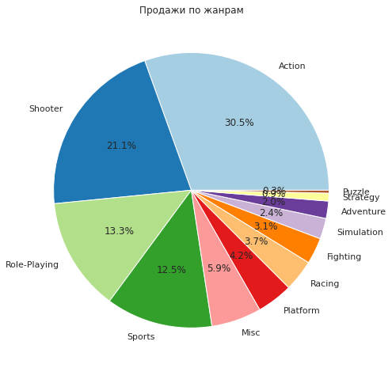

```python
sales_by_genres = rel_data.groupby('genre').agg({'total_sales': 'sum'}).sort_values(by='total_sales', ascending=False).reset_index()
sales_by_genres
fig, ax = plt.subplots()
colors = sns.color_palette("Paired")[:by_genres.genre.nunique()]
ax.pie(sales_by_genres['total_sales'], labels=sales_by_genres['genre'], colors = colors, autopct='%1.1f%%')
ax.set_title('Продажи по жанрам')
None
```

Сразу бросается в глаза то, что игры жарна *Adventure*, несмотря на большое их количество, занимают одно из последних мест по продажам.

**Самые продающиеся жанры:** Action, Shooter, Sports, Role-Playing, Misc

**Жанры с низкими продажами** Puzzle, Strategy, Adventure, Simulation, Fighting

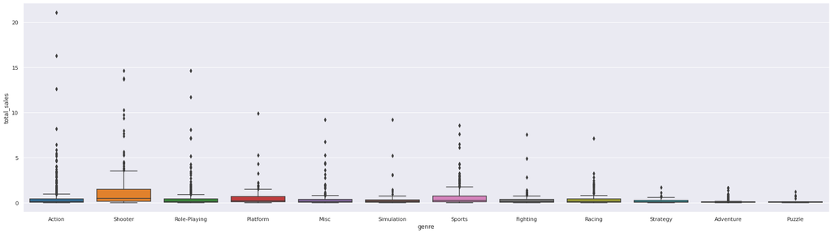

```python
colors = sns.color_palette("tab10")[:rel_data.platform.nunique()]
sns.boxplot(x='genre', y='total_sales', data=rel_data, notch=False, palette = colors)
```

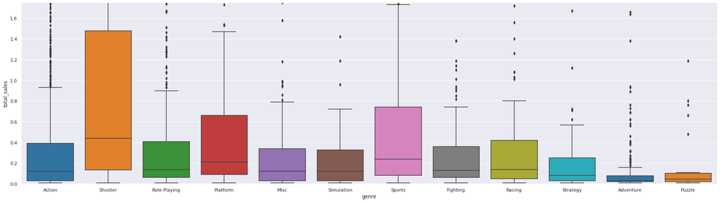

```python
sns.boxplot(x='genre', y='total_sales', data=rel_data, notch=False, palette = colors)
plt.ylim(0, 1.75)
None
```

Если же посмотреть графики размаха, можно увидеть, что самым популярным является жанр *Shooter*, *Sports*, *Platform*, за ними, неожиданно, идет *Racing* и замыкают пятерку игры жанра *Fighting*.

## Портрет пользователя каждого региона

Необходимо определить для пользователя каждого региона следующие параметры:

- Самые популярные платформы
- Самые популярные жанры
- Влияние рейтинга ESRB на продажи

### Самые популярные платформы

```python
eu_platforms = rel_data.groupby('platform').agg({'eu_sales': 'sum'}).sort_values(by = 'eu_sales', ascending=False)
na_platforms = rel_data.groupby('platform').agg({'na_sales': 'sum'}).sort_values(by = 'na_sales', ascending=False)
jp_platforms = rel_data.groupby('platform').agg({'jp_sales': 'sum'}).sort_values(by = 'jp_sales', ascending=False)

regions_platforms = eu_platforms.merge(na_platforms, how='outer', left_on='platform', right_on='platform').merge(jp_platforms, how='outer', left_on='platform', right_on='platform').reset_index()
print(eu_platforms.head().index.tolist())
print(na_platforms.head().index.tolist())
print(jp_platforms.head().index.tolist())
```

```
['PS4', 'PS3', 'X360', 'XOne', '3DS']
['X360', 'PS4', 'PS3', 'XOne', '3DS']
['3DS', 'PS3', 'PSV', 'PS4', 'WiiU']
```

- Топ-5 самых популярных платформ для региона **Европа**: PS4, PS3, X360, XOne, 3DS
- Топ-5 самых популярных платформ для региона **Северная Америка**: X360, PS4, PS3, XOne, 3DS
- Топ-5 самых популярных платформ для региона **Япония**: 3DS, PS3, PSV, PS4, WiiU

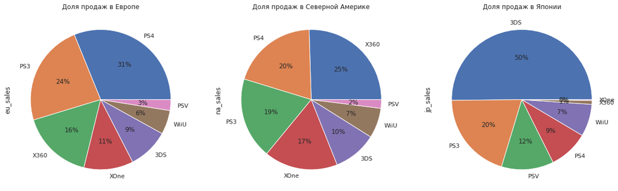

```python
regions_platforms = eu_platforms.merge(na_platforms, how='outer', left_on='platform', right_on='platform').merge(jp_platforms, how='outer', left_on='platform', right_on='platform')
top_platforms = []
for pl in regions_platforms.index:
    if pl in eu_platforms.head().index.tolist() or pl in na_platforms.head().index.tolist() or pl in jp_platforms.head().index.tolist():
        top_platforms.append(pl)
top_regions_platforms = regions_platforms.query('platform in @top_platforms')

eu_top_pl = top_regions_platforms['eu_sales']
na_top_pl = top_regions_platforms.sort_values(by = 'na_sales', ascending=False)['na_sales']
jp_top_pl = top_regions_platforms.sort_values(by = 'jp_sales', ascending=False)['jp_sales']

fig, axes = plt.subplots(ncols=3, figsize = (20,10))
eu_top_pl.plot(ax=axes[0], kind = 'pie', subplots=True, autopct='%1.0f%%', legend = False);
axes[0].set_title('Доля продаж в Европе')
na_top_pl.plot(ax=axes[1], kind = 'pie', subplots=True, autopct='%1.0f%%', legend = False);
axes[1].set_title('Доля продаж в Северной Америке')
jp_top_pl.plot(ax=axes[2], kind = 'pie', subplots=True, autopct='%1.0f%%', legend = False);
axes[2].set_title('Доля продаж в Японии')

None
```

По графиками можно сказать, что аудитория из Европы и Северной Америки имеет довольно много общего в плане выбора платформ, в то время как Япония сильно отличается, там половину рынка занимает 3DS, а XBox 360 b ХBox One крайне не популярны.

### Самые популярные жанры

```python
eu_genres = rel_data.groupby(['genre']).agg({'eu_sales': 'sum'}).sort_values(by = 'eu_sales', ascending=False)
na_genres = rel_data.groupby('genre').agg({'na_sales': 'sum'}).sort_values(by = 'na_sales', ascending=False)
jp_genres = rel_data.groupby('genre').agg({'jp_sales': 'sum'}).sort_values(by = 'jp_sales', ascending=False)

regions_genres = eu_genres.merge(na_genres, how='outer', left_on='genre', right_on='genre').merge(jp_genres, how='outer', left_on='genre', right_on='genre').reset_index()
print(eu_genres.head().index.tolist())
print(na_genres.head().index.tolist())
print(jp_genres.head().index.tolist())
```

```
['Action', 'Shooter', 'Sports', 'Role-Playing', 'Racing']
['Action', 'Shooter', 'Sports', 'Role-Playing', 'Misc']
['Role-Playing', 'Action', 'Misc', 'Simulation', 'Fighting']
```

Построим график, чтобы проще было сравнить разницу.

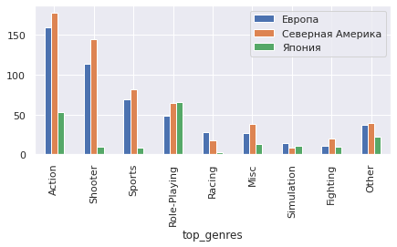

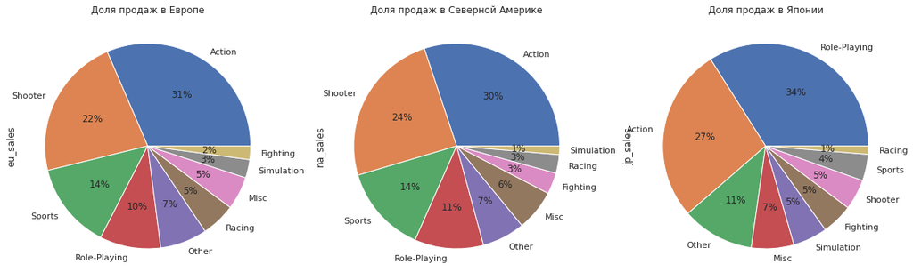

```python
top_genre = []
other = 'other_genres'
for gen in regions_genres['genre']:
    if gen in eu_genres.head().index.tolist() or gen in na_genres.head().index.tolist() or gen in jp_genres.head().index.tolist():
        top_genre.append(gen)

def top_gen(row):
    genre = row['genre']
    if genre in top_genre:
        return genre
    else:
        return other

cols = ['eu_sales', 'na_sales', 'jp_sales']
top_regions_genres = regions_genres
top_regions_genres['top_genres'] = top_regions_genres.apply(top_gen, axis=1)
other_sum = top_regions_genres.query('top_genres in @other')[cols].sum()
top_regions_genres = top_regions_genres.append(other_sum, ignore_index=True)
top_regions_genres = top_regions_genres.query('top_genres != "other_genres"').fillna("Other")
top_regions_genres

top_regions_genres.index = top_regions_genres['top_genres']
top_regions_genres.plot(kind='bar', figsize=(7, 3))
plt.legend(labels=['Европа', 'Северная Америка', 'Япония'])
None

eu_top_gen = top_regions_genres.sort_values(by = 'eu_sales', ascending=False)['eu_sales']
na_top_gen = top_regions_genres.sort_values(by = 'na_sales', ascending=False)['na_sales']
jp_top_gen = top_regions_genres.sort_values(by = 'jp_sales', ascending=False)['jp_sales']

fig, axes = plt.subplots(ncols=3, figsize = (20,10))
eu_top_gen.plot(ax=axes[0], kind = 'pie', subplots=True, autopct='%1.0f%%', legend = False);
axes[0].set_title('Доля продаж в Европе')
na_top_gen.plot(ax=axes[1], kind = 'pie', subplots=True, autopct='%1.0f%%', legend = False);
axes[1].set_title('Доля продаж в Северной Америке')
jp_top_gen.plot(ax=axes[2], kind = 'pie', subplots=True, autopct='%1.0f%%', legend = False);
axes[2].set_title('Доля продаж в Японии')

None
```

В то же время в Японии больше половины прибыли приносят игры жанра *Role-Playing* (34%) и *Action* (27%), а остальные жанры приносят менее 10% прибыли, при чем жанры *Fighting*, *Shooter* и *Simulation* занимают одинаковую долю рынка (5%).

### Влияние рейтинга

Для начала, посмотрим какие рейтинги есть в таблице и что они означают.

```python
rel_data['rating'].unique()
```

```
array(['M', 'unknown', 'E', 'E10+', 'T'], dtype=object)
```

Расшифровка рейтингов:

- **EC** Для детей младшего возраста. Подходит для детей от 3 лет, неприемлемое содержание отсутствует. Примеры: Дора Исследовательница, Сказки Дракона.
- **E** Подходит для всех возрастных категорий. Игра не должна содержать звуков или изображений, которые могут напугать маленьких детей. Не должна использоваться ненормативная лексика. Примеры: Просто таннцуй, FIFA.
- **E 10+** Подходит для лиц старше 10 лет. Игра может содержать умеренные формы насилия, а некоторые сцены могут пугать детей. Примеры: Minecraft Dungeons, Растения против зомби.
- **T** Подходит для лиц старше 13 лет. Игра может содержать более реалистичные и натуралистические сцены насилия. Примеры: Fortnite, Sims 4.
- **M** Подходит для лиц старше 17 лет. Этот рейтинг используется, когда насилие становится реалистичным и похожим на реальную жизнь. Также может присутствовать ненормативная лексика, употребление табака, алкоголя или запрещенных наркотиков. Примеры: Ark: Survival Evolved, Destiny 2.
- **RP** Категория ещё не присвоена. Играм с категорией RP еще не присвоен окончательный рейтинг ESRB.

```python
eu_rates = rel_data.groupby(['rating']).agg({'eu_sales': 'sum'}).sort_values(by = 'eu_sales', ascending=False)
na_rates = rel_data.groupby(['rating']).agg({'na_sales': 'sum'}).sort_values(by = 'na_sales', ascending=False)
jp_rates = rel_data.groupby(['rating']).agg({'jp_sales': 'sum'}).sort_values(by = 'jp_sales', ascending=False)
```

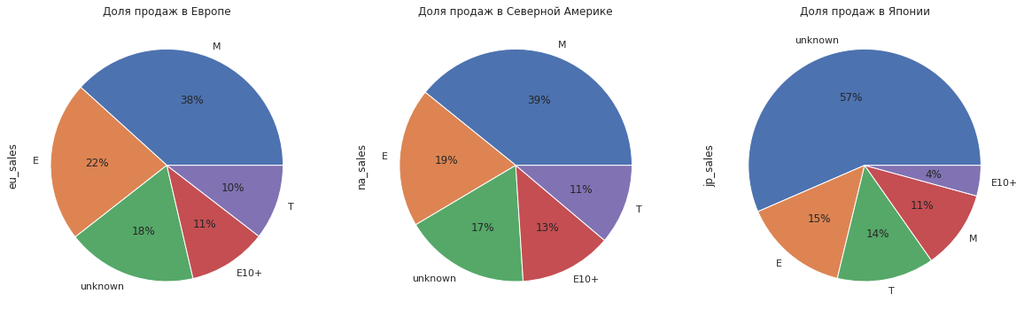

```python
fig, axes = plt.subplots(ncols=3, figsize = (20,10))
eu_rates.plot(ax=axes[0], kind = 'pie', subplots=True, autopct='%1.0f%%', legend = False);
axes[0].set_title('Доля продаж в Европе')
na_rates.plot(ax=axes[1], kind = 'pie', subplots=True, autopct='%1.0f%%', legend = False);
axes[1].set_title('Доля продаж в Северной Америке')
jp_rates.plot(ax=axes[2], kind = 'pie', subplots=True, autopct='%1.0f%%', legend = False);
axes[2].set_title('Доля продаж в Японии')
None
```

И вновь Европа и Северная Америка показывают удивительную схожесть во вкусах: диаграммы практически идентичны.

Япония же снова отличилась: первое место занимают игры без рейтинга, затем идут игры без возрастных ограничений (*E*), а наиболее популярный для Европы и Северной Америки рейтинг *M* занимает лишь 4 место.

## Проверка гипотез

### Средние пользовательские рейтинги платформ *Xbox One* и *PC* одинаковые

- H_0: Средние пользовательские рейтинги платформ Xbox One и PC **одинаковые**
- H_a: Средние пользовательские рейтинги платформ Xbox One и PC **различаются**

```python
hyp_data = data.query('year_of_release>2012').query('user_score>=0')
hyp1_xone = hyp_data.query('platform == "XOne"')['user_score']
hyp1_pc = hyp_data.query('platform == "PC"')['user_score']
```

```python
hyp1_xone
```

```
165      7.9
179      5.4
242      6.4
270      6.2
373      4.1
        ...
16542    6.8
16595    6.0
16628    8.2
16641    6.6
16658    6.7
Name: user_score, Length: 182, dtype: float64
```

```python
np.var(hyp1_xone)
```

```
1.8965188383045526
```

```python
np.var(hyp1_pc)
```

```
3.016306347554631
```

Дисперсии сильно отличаются, установим **equal_var=False**

```python
results = st.ttest_ind(hyp1_xone, hyp1_pc, equal_var=False)

alpha = .05


if results.pvalue < alpha:
    print('p-значение:', results.pvalue)
    print('Отвергаем нулевую гипотезу')
else:
    print('p-значение:', results.pvalue)
    print('Не получилось отвергнуть нулевую гипотезу')
```

```
p-значение: 0.14759594013430463
Не получилось отвергнуть нулевую гипотезу
```

Не получилось отвергнуть нудевую гипотезу, следовательно, мы будем придерживаться её и считать, что **средние пользовательские рейтинги одинаковы.**

```python
hyp1_xone.mean()-hyp1_pc.mean()
```

```
0.2517511520737328
```

Средние показатели подтверждают результаты статистического анализа: при оценке по 10-бальной системе, средние значения различаются лишь на 0,25, что составляет 2,5%

### Средние пользовательские рейтинги жанров *Action* и *Sports* разные

- H_0: Средние пользовательские рейтинги жанров Action и Sports **одинаковые**
- H_a: Средние пользовательские рейтинги жанров Action и Sports **разные**

```python
hyp2_data = data.query('year_of_release>2009').query('user_score>=0')
hyp2_act = hyp_data.query('genre == "Action"')['user_score']
hyp2_sp = hyp_data.query('genre == "Sports"')['user_score']
```

```python
np.var(hyp2_act)
```

```
1.7648124186332366
```

```python
np.var(hyp2_sp)
```

```
3.160733984375
```

```python
results = st.ttest_ind(hyp2_act, hyp2_sp)

alpha = .05


if results.pvalue < alpha:
    print('p-значение:', results.pvalue)
    print('Отвергаем нулевую гипотезу')
else:
    print('p-значение:', results.pvalue)
    print('Не получилось отвергнуть нулевую гипотезу')
```

```
p-значение: 1.0517832389140023e-27
Отвергаем нулевую гипотезу
```

Мы отвергаем нулевую гипотезу и придерживаемся альтернативной: **Оценки пользователей для игр жанров *Action* и *Sports* разные.**

```python
hyp2_act.mean()-hyp2_sp.mean()
```

```
1.5994071336760927
```